# Final project SHDM

```python
import numpy as np
import pandas as pd
import seaborn as sns
import math
import scipy.stats as stats
from scipy.stats import ttest_1samp,ttest_ind,ttest_rel
import matplotlib as plt
```

```python
mydata=pd.read_csv('Wholesale Customer.csv')
mydata.head()
```

|  | Buyer/Spender | Channel | Region | Fresh | Milk | Grocery | Frozen | Detergents_Paper | Delicatessen |
| --- | --- | --- | --- | --- | --- | --- | --- | --- | --- |
| 0 | 1 | Retail | Other | 12669 | 9656 | 7561 | 214 | 2674 | 1338 |
| 1 | 2 | Retail | Other | 7057 | 9810 | 9568 | 1762 | 3293 | 1776 |
| 2 | 3 | Retail | Other | 6353 | 8808 | 7684 | 2405 | 3516 | 7844 |
| 3 | 4 | Hotel | Other | 13265 | 1196 | 4221 | 6404 | 507 | 1788 |
| 4 | 5 | Retail | Other | 22615 | 5410 | 7198 | 3915 | 1777 | 5185 |

```python
df = mydata.drop('Buyer/Spender',axis=1)
df.head()
```

|  | Channel | Region | Fresh | Milk | Grocery | Frozen | Detergents_Paper | Delicatessen |
| --- | --- | --- | --- | --- | --- | --- | --- | --- |
| 0 | Retail | Other | 12669 | 9656 | 7561 | 214 | 2674 | 1338 |
| 1 | Retail | Other | 7057 | 9810 | 9568 | 1762 | 3293 | 1776 |
| 2 | Retail | Other | 6353 | 8808 | 7684 | 2405 | 3516 | 7844 |
| 3 | Hotel | Other | 13265 | 1196 | 4221 | 6404 | 507 | 1788 |
| 4 | Retail | Other | 22615 | 5410 | 7198 | 3915 | 1777 | 5185 |

```python
df.groupby("Channel").describe().max().head(1)
```

```
Fresh  count    298.0
dtype: float64
```

```python
df.groupby("Channel").describe()
```

| Channel | Fresh count | Fresh mean | Fresh std | Fresh min | Fresh 25% | Fresh 50% | Fresh 75% | Fresh max | Milk count | Milk mean | ... | Detergents_Paper 75% | Detergents_Paper max | Delicatessen count | Delicatessen mean | Delicatessen std | Delicatessen min | Delicatessen 25% | Delicatessen 50% | Delicatessen 75% | Delicatessen max |
| --- | --- | --- | --- | --- | --- | --- | --- | --- | --- | --- | --- | --- | --- | --- | --- | --- | --- | --- | --- | --- | --- |
| Hotel | 298.0 | 13475.560403 | 13831.687502 | 3.0 | 4070.25 | 9581.5 | 18274.75 | 112151.0 | 298.0 | 3451.724832 | ... | 899.5 | 6907.0 | 298.0 | 1415.956376 | 3147.426922 | 3.0 | 379.00 | 821.0 | 1548.0 | 47943.0 |
| Retail | 142.0 | 8904.323944 | 8987.714750 | 18.0 | 2347.75 | 5993.5 | 12229.75 | 44466.0 | 142.0 | 10716.500000 | ... | 8662.5 | 40827.0 | 142.0 | 1753.436620 | 1953.797047 | 3.0 | 566.75 | 1350.0 | 2156.0 | 16523.0 |

2 rows × 48 columns

```python
df.groupby("Region").describe()
```

| Region | Fresh count | Fresh mean | Fresh std | Fresh min | Fresh 25% | Fresh 50% | Fresh 75% | Fresh max | Milk count | Milk mean | ... | Detergents_Paper 75% | Detergents_Paper max | Delicatessen count | Delicatessen mean | Delicatessen std | Delicatessen min | Delicatessen 25% | Delicatessen 50% | Delicatessen 75% | Delicatessen max |
| --- | --- | --- | --- | --- | --- | --- | --- | --- | --- | --- | --- | --- | --- | --- | --- | --- | --- | --- | --- | --- | --- |
| Lisbon | 77.0 | 11101.727273 | 11557.438575 | 18.0 | 2806.00 | 7363.0 | 15218.0 | 56083.0 | 77.0 | 5486.415584 | ... | 3593.00 | 19410.0 | 77.0 | 1354.896104 | 1345.423340 | 7.0 | 548.0 | 806.0 | 1775.00 | 6854.0 |
| Oporto | 47.0 | 9887.680851 | 8387.899211 | 3.0 | 2751.50 | 8090.0 | 14925.5 | 32717.0 | 47.0 | 5088.170213 | ... | 4324.50 | 38102.0 | 47.0 | 1159.702128 | 1050.739841 | 51.0 | 540.5 | 898.0 | 1538.50 | 5609.0 |
| Other | 316.0 | 12533.471519 | 13389.213115 | 3.0 | 3350.75 | 8752.5 | 17406.5 | 112151.0 | 316.0 | 5977.085443 | ... | 3875.75 | 40827.0 | 316.0 | 1620.601266 | 3232.581660 | 3.0 | 402.0 | 994.0 | 1832.75 | 47943.0 |

3 rows × 48 columns

```python
df.Channel.value_counts()
```

```
Hotel     298
Retail    142
Name: Channel, dtype: int64
```

Problem 1 A wholesale distributor operating in different regions of Portugal has information on annual spending of several items in their stores across different regions and channels. The data (Wholesale Customer.csv) consists of 440 large retailers’ annual spending on 6 different varieties of products in 3 different regions (Lisbon, Oporto, Other) and across different sales channel (Hotel, Retail).

1.1. Use methods of descriptive statistics to summarize data. Which Region and which Channel seems to spend more? Which Region and which Channel seems to spend less?

Method 1:

```python
df.groupby(['Channel']).size().sort_values(ascending=False).reset_index().head(1)
```

|  | Channel | 0 |
| --- | --- | --- |
| 0 | Hotel | 298 |

```python
df.groupby(['Channel']).size().sort_values(ascending=False).reset_index().tail(1)
```

|  | Channel | 0 |
| --- | --- | --- |
| 1 | Retail | 142 |

```python
df.groupby(['Region']).size().sort_values(ascending=False).reset_index().head(1)
```

|  | Region | 0 |
| --- | --- | --- |
| 0 | Other | 316 |

```python
df.groupby(['Region']).size().sort_values(ascending=False).reset_index().tail(1)
```

|  | Region | 0 |
| --- | --- | --- |
| 2 | Oporto | 47 |

Method 2:

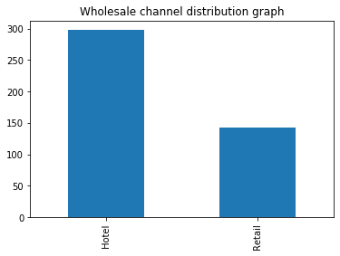

```python
df['Channel'].value_counts().plot(kind='bar',title='Wholesale channel distribution graph')
```

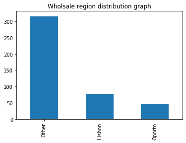

```python
df['Region'].value_counts().plot(kind='bar',title='Wholsale region distribution graph')
```

1.2. There are 6 different varieties of items are considered. Do all varieties show similar behaviour across Region and Channel?

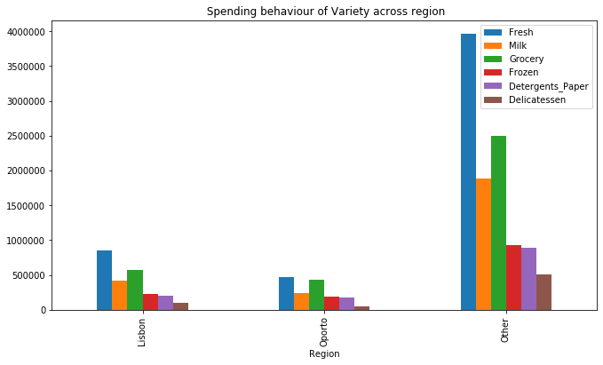

```python
df_region = df[["Region","Fresh","Milk","Grocery","Frozen","Detergents_Paper","Delicatessen"]]
df_region.groupby("Region").sum().plot(kind="bar",figsize = (11,6),title=" Spending behaviour of Variety across region")
```

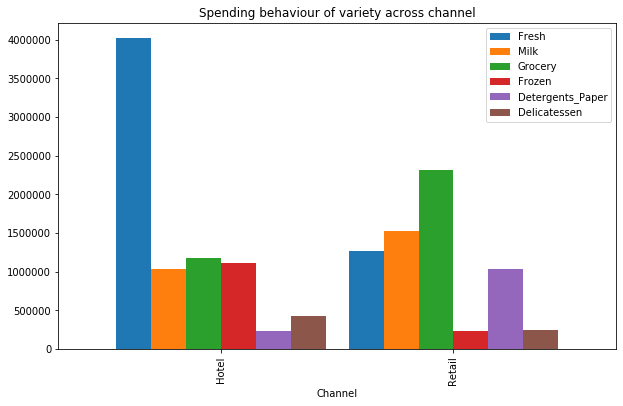

```python
df_Channel=df[["Channel","Fresh","Milk","Grocery","Frozen","Detergents_Paper","Delicatessen"]]
df_Channel.groupby("Channel").sum().plot(kind="bar",width=0.9,figsize = (10,6),title="Spending behaviour of variety across channel")
```

1.3. On the basis of the descriptive measure of variability, which item shows the most inconsistent behaviour? Which items shows the least inconsistent behaviour?

```python
df.std()/df.mean()
```

```
Fresh               1.053918
Milk                1.273299
Grocery             1.195174
Frozen              1.580332
Detergents_Paper    1.654647
Delicatessen        1.849407
dtype: float64
```

```python
df.skew()
```

```
Fresh                2.561323
Milk                 4.053755
Grocery              3.587429
Frozen               5.907986
Detergents_Paper     3.631851
Delicatessen        11.151586
dtype: float64
```

1.4. Are there any outliers in the data?

```python
# Outlier detection using IQR method:
Q1 = df.quantile(0.25)
Q3 = df.quantile(0.75)
IQR = Q3 - Q1
print(IQR)
```

```
Fresh               13806.00
Milk                 5657.25
Grocery              8502.75
Frozen               2812.00
Detergents_Paper     3665.25
Delicatessen         1412.00
dtype: float64
```

```python
((df < (Q1 - 1.5 * IQR)) | (df > (Q3 + 1.5 * IQR))).sum()
```

```
Channel              0
Delicatessen        27
Detergents_Paper    30
Fresh               20
Frozen              43
Grocery             24
Milk                28
Region               0
dtype: int64
```

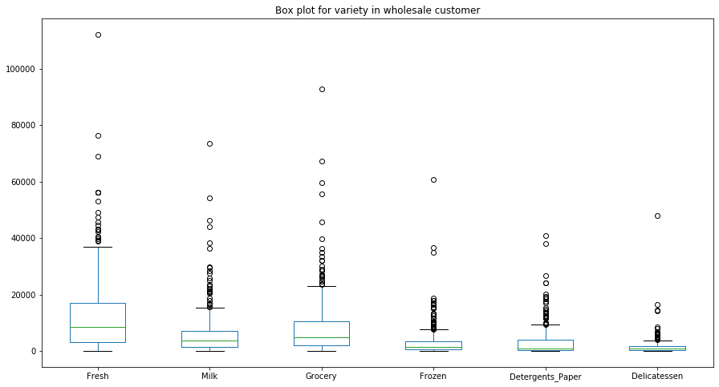

```python
df.plot(kind='box', figsize=(15,8),title='Box plot for variety in wholesale customer')
```

```python
df.skew()
```

```
Fresh                2.561323
Milk                 4.053755
Grocery              3.587429
Frozen               5.907986
Detergents_Paper     3.631851
Delicatessen        11.151586
dtype: float64
```

1.5. On the basis of this report, what are the recommendations?

Problem 2

The Student News Service at Clear Mountain State University (CMSU) has decided to gather data about the undergraduate students that attend CMSU. CMSU creates and distributes a survey of 14 questions and receives responses from 62 undergraduates (stored in the Survey.csv file).

```python
df_survey=pd.read_csv('Survey-1.csv')
df_survey.head(62)
```

|  | ID | Gender | Age | Class | Major | Grad Intention | GPA | Employment | Salary | Social Networking | Satisfaction | Spending | Computer | Text Messages |
| --- | --- | --- | --- | --- | --- | --- | --- | --- | --- | --- | --- | --- | --- | --- |
| 0 | 1 | Female | 20 | Junior | Other | Yes | 2.9 | Full-Time | 50.0 | 1 | 3 | 350 | Laptop | 200 |
| 1 | 2 | Male | 23 | Senior | Management | Yes | 3.6 | Part-Time | 25.0 | 1 | 4 | 360 | Laptop | 50 |
| 2 | 3 | Male | 21 | Junior | Other | Yes | 2.5 | Part-Time | 45.0 | 2 | 4 | 600 | Laptop | 200 |
| 3 | 4 | Male | 21 | Junior | CIS | Yes | 2.5 | Full-Time | 40.0 | 4 | 6 | 600 | Laptop | 250 |
| 4 | 5 | Male | 23 | Senior | Other | Undecided | 2.8 | Unemployed | 40.0 | 2 | 4 | 500 | Laptop | 100 |
| ... | ... | ... | ... | ... | ... | ... | ... | ... | ... | ... | ... | ... | ... | ... |
| 57 | 58 | Female | 21 | Senior | International Business | No | 2.4 | Part-Time | 40.0 | 1 | 3 | 1000 | Laptop | 10 |
| 58 | 59 | Female | 20 | Junior | CIS | No | 2.9 | Part-Time | 40.0 | 2 | 4 | 350 | Laptop | 250 |
| 59 | 60 | Female | 20 | Sophomore | CIS | No | 2.5 | Part-Time | 55.0 | 1 | 4 | 500 | Laptop | 500 |
| 60 | 61 | Female | 23 | Senior | Accounting | Yes | 3.5 | Part-Time | 30.0 | 2 | 3 | 490 | Laptop | 50 |
| 61 | 62 | Female | 23 | Senior | Economics/Finance | No | 3.2 | Part-Time | 70.0 | 2 | 3 | 250 | Laptop | 0 |

62 rows × 14 columns

2.1. For this data, construct the following contingency tables (Keep Gender as row variable) 2.1.1. Gender and Major 2.1.2. Gender and Grad Intention 2.1.3. Gender and Employment 2.1.4. Gender and Computer

```python
df_crosstab1 = pd.crosstab(df_survey['Gender'],
                         df_survey['Major'],
                         margins = True,margins_name="Total")
df_crosstab1
```

| Major Gender | Accounting | CIS | Economics/Finance | International Business | Management | Other | Retailing/Marketing | Undecided | Total |
| --- | --- | --- | --- | --- | --- | --- | --- | --- | --- |
| Female | 3 | 3 | 7 | 4 | 4 | 3 | 9 | 0 | 33 |
| Male | 4 | 1 | 4 | 2 | 6 | 4 | 5 | 3 | 29 |
| Total | 7 | 4 | 11 | 6 | 10 | 7 | 14 | 3 | 62 |

```python
df_crosstab2 = pd.crosstab(df_survey['Gender'],
                          df_survey['Grad Intention'],
                          margins = True,margins_name="Total")
df_crosstab2
```

| Grad Intention Gender | No | Undecided | Yes | Total |
| --- | --- | --- | --- | --- |
| Female | 9 | 13 | 11 | 33 |
| Male | 3 | 9 | 17 | 29 |
| Total | 12 | 22 | 28 | 62 |

```python
df_crosstab3 = pd.crosstab(df_survey['Gender'],
                          df_survey['Employment'],
                          margins = True,margins_name="Total")
df_crosstab3
```

| Employment Gender | Full-Time | Part-Time | Unemployed | Total |
| --- | --- | --- | --- | --- |
| Female | 3 | 24 | 6 | 33 |
| Male | 7 | 19 | 3 | 29 |
| Total | 10 | 43 | 9 | 62 |

```python
df_crosstab4 = pd.crosstab(df_survey['Gender'],
                          df_survey['Computer'],
                          margins = True,margins_name="Total")
df_crosstab4
```

| Computer Gender | Desktop | Laptop | Tablet | Total |
| --- | --- | --- | --- | --- |
| Female | 2 | 29 | 2 | 33 |
| Male | 3 | 26 | 0 | 29 |
| Total | 5 | 55 | 2 | 62 |

2.2. Assume that the sample is a representative of the population of CMSU. Based on the data, answer the following questions:

2.2.1. What is the probability that a randomly selected CMSU student will be male? What is the probability that a randomly selected CMSU student will be female?

```python
df_survey['Gender'].value_counts()
```

```
Female    33
Male      29
Name: Gender, dtype: int64
```

```python
len(df_survey)
```

```
62
```

What is the probability that a randomly selected CMSU student will be male?

```python
# P(Number of Male/Total number of student)
29/62
```

```
0.46774193548387094
```

What is the probability that a randomly selected CMSU student will be female?

```python
# P(Number of Female/Total number of student)
33/62
```

```
0.532258064516129
```

2.2.2. Find the conditional probability of different majors among the male students in CMSU. Find the conditional probability of different majors among the female students of CMSU.

```python
df_crosstab1 = pd.crosstab(df_survey['Gender'],
                         df_survey['Major'],
                         margins = True,margins_name="Total")
df_crosstab1
```

| Major Gender | Accounting | CIS | Economics/Finance | International Business | Management | Other | Retailing/Marketing | Undecided | Total |
| --- | --- | --- | --- | --- | --- | --- | --- | --- | --- |
| Female | 3 | 3 | 7 | 4 | 4 | 3 | 9 | 0 | 33 |
| Male | 4 | 1 | 4 | 2 | 6 | 4 | 5 | 3 | 29 |
| Total | 7 | 4 | 11 | 6 | 10 | 7 | 14 | 3 | 62 |

a)Find the conditional probability of Accounting as majors among the male students in CMSU.

```python
# P(Accounting /Male)
4/29
```

```
0.13793103448275862
```

Find the conditional probability of Accounting as majors among the female students of CMSU.

```python
# P(Accounting/Female)
(3/33)
```

```
0.09090909090909091
```

b)Find the conditional probability of CIS among the male students in CMSU.

```python
# P(CIS/Male)
1/29
```

```
0.034482758620689655
```

Find the conditional probability of CIS among the female students of CMSU.

```python
# P(CIS/Female)
3/33
```

```
0.09090909090909091
```

c)Find the conditional probability of Economics/Finance among the male students in CMSU.

```python
# P(Economics /Finance/Male)
4/29
```

```
0.13793103448275862
```

```python
# P(Economics /Finance/Female)
7/33
```

```
0.21212121212121213
```

d)Find the conditional probability of International Business among the male students in CMSU.

```python
# P(International Business/Male)
2/29
```

```
0.06896551724137931
```

```python
# P(International Business/Male)
4/33
```

```
0.12121212121212122
```

e)Find the conditional probability of Management among the male students in CMSU.

```python
# P(Management /Male)
6/29
```

```
0.20689655172413793
```

```python
# P(Management /Female)
4/33
```

```
0.12121212121212122
```

f)Find the conditional probability of others among the male students in CMSU.

```python
# P(Others/Male)
4/29
```

```
0.13793103448275862
```

```python
# P(Others/Female)
3/33
```

```
0.09090909090909091
```

g)Find the conditional probability of Retailing/Marketing among the male students in CMSU.

```python
# P(Retailing 0r Marketing/Male)
5/29
```

```
0.1724137931034483
```

```python
# P(Retailing 0r Marketing/Female)
9/33
```

```
0.2727272727272727
```

h)Find the conditional probability of Undecided among the male students in CMSU.

```python
# P(Undecided/Male)
3/29
```

```
0.10344827586206896
```

```python
# P(Undecided/Female)
0/33
```

```
0.0
```

2.2.3. Find the conditional probability of intent to graduate, given that the student is a male. Find the conditional probability of intent to graduate, given that the student is a female.

```python
df_crosstab2 = pd.crosstab(df_survey['Gender'],
                          df_survey['Grad Intention'],
                          margins = True,margins_name="Total")
df_crosstab2
```

| Grad Intention Gender | No | Undecided | Yes | Total |
| --- | --- | --- | --- | --- |
| Female | 9 | 13 | 11 | 33 |
| Male | 3 | 9 | 17 | 29 |
| Total | 12 | 22 | 28 | 62 |

```python
# P(Intent to graduate and Male/P(Male))
17/29
```

```
0.5862068965517241
```

```python
# P(Intent to graduate and Female/Female)
11/33
```

```
0.3333333333333333
```

2.2.4. Find the conditional probability of employment status for the male students as well as for the female students.

```python
df_crosstab3 = pd.crosstab(df_survey['Gender'],
                          df_survey['Employment'],
                          margins = True,margins_name="Total")
df_crosstab3
```

| Employment Gender | Full-Time | Part-Time | Unemployed | Total |
| --- | --- | --- | --- | --- |
| Female | 3 | 24 | 6 | 33 |
| Male | 7 | 19 | 3 | 29 |
| Total | 10 | 43 | 9 | 62 |

```python
# The probability of Full time employment for Male student:
7/29
```

```
0.2413793103448276
```

```python
# The probability of Full time employment for Female student:
3/33
```

```
0.09090909090909091
```

```python
# The probability of Part time employment for Male student:
19/29
```

```
0.6551724137931034
```

```python
# The probability of Part time employment for Female student:
24/33
```

```
0.7272727272727273
```

```python
# The probability of unemployed for Male student:
3/29
```

```
0.10344827586206896
```

```python
# The probability of unemployed for Female student:
6/33
```

```
0.18181818181818182
```

2.2.5. Find the conditional probability of laptop preference among the male students as well as among the female students.

```python
df_crosstab4 = pd.crosstab(df_survey['Gender'],
                          df_survey['Computer'],
                          margins = True,margins_name="Total")
df_crosstab4
```

| Computer Gender | Desktop | Laptop | Tablet | Total |
| --- | --- | --- | --- | --- |
| Female | 2 | 29 | 2 | 33 |
| Male | 3 | 26 | 0 | 29 |
| Total | 5 | 55 | 2 | 62 |

```python
# The probability of laptop preference among Male student:
26/29
```

```
0.896551724137931
```

```python
# The probability of laptop preference among Female student:
29/33
```

```
0.8787878787878788
```

2.3. Based on the above probabilities, do you think that the column variable in each case is independent of Gender? Justify your comment in each case.

```python
# P(F and accounting as their major )
3/62
```

```
0.04838709677419355
```

```python
# P(F).P(accounting as their major)
33/62*7/62
```

```
0.060093652445369405
```

```python
# P(F and CIS as their major )
3/62
```

```
0.04838709677419355
```

```python
# P(F).P(CIS as their major)
33/62*4/62
```

```
0.03433922996878252
```

```python
# P(F and Economics/Finance as their major)
7/62
```

```
0.11290322580645161
```

```python
# P(F).P(Economics/Finance as their major)
33/62*11/62
```

```
0.09443288241415192
```

```python
# P(F and International Business as their major)
4/62
```

```
0.06451612903225806
```

```python
# P(F).P(International Business as their major)
33/62*6/62
```

```
0.051508844953173774
```

```python
# P(F and Management as their major)
4/62
```

```
0.06451612903225806
```

```python
# P(F).P(Management as their major)
33/62*10/62
```

```
0.08584807492195629
```

```python
# P(F and other as their major)
3/62
```

```
0.04838709677419355
```

```python
# P(F).P(other as their major)
33/62*7/62
```

```
0.060093652445369405
```

```python
# P(F and Retailing/Marketing as major)
9/62
```

```
0.14516129032258066
```

```python
# P(F).P(Retailing/Marketing as major)
33/62*14/62
```

```
0.12018730489073881
```

```python
# P(F and Undecided as major)
0/62
```

```
0.0
```

```python
# P(F).P(Undecided as major)
33/62*3/62
```

```
0.025754422476586887
```

```python
# P(F and Intent to graduate)
11/62
```

```
0.1774193548387097
```

```python
# P(F).P(Intent to graduate)
33/62*28/62
```

```
0.24037460978147762
```

```python
# P(F and Full_Time)
3/62
```

```
0.04838709677419355
```

```python
# P(F).P(Full_Time)
33/62*10/62
```

```
0.08584807492195629
```

```python
# P(F and Part_Time)
24/62
```

```
0.3870967741935484
```

```python
# P(F).P(Part_Time)
33/62*43/62
```

```
0.3691467221644121
```

```python
# P(F and Unemployed)
6/62
```

```
0.0967741935483871
```

```python
# P(F).P(Unemployed)
33/62*9/62
```

```
0.07726326742976067
```

```python
# P(F and Laptop Preference)
29/62
```

```
0.46774193548387094
```

```python
# P(F).P(Lpatop Preference)
33/62*55/62
```

```
0.4721644120707596
```

Part II

```
2.4. Note that there are three numerical (continuous) variables in the data set, Salary, Spending and Text Messages.
For each of them comment whether they follow a normal distribution.
Write a note summarizing your conclusions.
[Recall that symmetric histogram does not necessarily mean that the underlying distribution is symmetric]
```

```python
Skewness = pd.DataFrame({'Skewness' : [stats.skew(df_survey['Salary']),stats.skew(df_survey['Spending']),stats.skew(df_survey['Text Messages'])]},
                        index=['Salary','Spending','Text Messages'])
Skewness
```

|  | Skewness |
| --- | --- |
| Salary | 0.521677 |
| Spending | 1.547285 |
| Text Messages | 1.264245 |

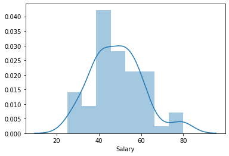

```python
Salary=df_survey.Salary.sort_values()
Salary
sns.distplot(Salary)
```

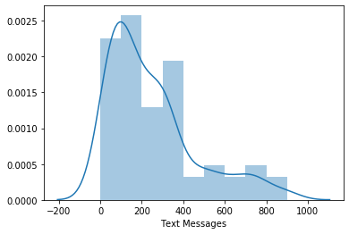

```python
Text_Messages=df_survey['Text Messages']
Text_Messages
sns.distplot(Text_Messages)
```

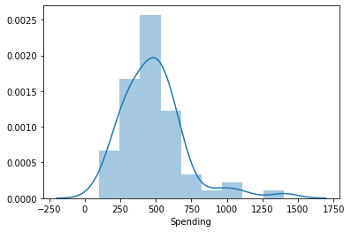

```python
Spending=df_survey.Spending.sort_values()
Spending
sns.distplot(Spending)
```

Problem 3

An important quality characteristic used by the manufacturers of ABC asphalt shingles is the amount of moisture the shingles contain when they are packaged. Customers may feel that they have purchased a product lacking in quality if they find moisture and wet shingles inside the packaging. In some cases, excessive moisture can cause the granules attached to the shingles for texture and colouring purposes to fall off the shingles resulting in appearance problems.

To monitor the amount of moisture present, the company conducts moisture tests.

A shingle is weighed and then dried. The shingle is then reweighed, and based on the amount of moisture taken out of the product, the pounds of moisture per 100 square feet is calculated. The company claims that the mean moisture content cannot be greater than 0.35 pound per 100 square feet. The file (A & B shingles.csv) includes 36 measurements (in pounds per 100 square feet) for A shingles and 31 for B shingles.

For the A shingles, the null and alternative hypothesis to test whether the population mean moisture content is less than 0.35 pound per 100 square feet is given:

LaTeX: H_0<=0.35

LaTeX: H_A>0.35

For the B shingles, the null and alternative hypothesis to test whether the population mean moisture content is less than 0.35 pound per 100 square feet is given:

LaTeX: H_0<=0.35

LaTeX: H_A>0.35

3.1 Do you think that the population means for shingles A and B are equal? Form the hypothesis and conduct the test of the hypothesis. What assumption do you need to check before the test for equality of means is performed?

3.2 What assumption about the population distribution is needed in order to conduct the hypothesis tests above?

```python
df=pd.read_csv('A & B shingles-1.csv')
df.head()
```

|  | A | B |
| --- | --- | --- |
| 0 | 0.44 | 0.14 |
| 1 | 0.61 | 0.15 |
| 2 | 0.47 | 0.31 |
| 3 | 0.30 | 0.16 |
| 4 | 0.15 | 0.37 |

```python
dfA=df['A']
dfA.head()
```

```
0    0.44
1    0.61
2    0.47
3    0.30
4    0.15
Name: A, dtype: float64
```

```python
dfB=df['B'].dropna()
dfB.head()
```

```
0    0.14
1    0.15
2    0.31
3    0.16
4    0.37
Name: B, dtype: float64
```

3.1 Do you think that the population means for shingles A and B are equal? Form the hypothesis and conduct the test of the hypothesis. What assumption do you need to check before the test for equality of means is performed?

The independent samples t test and also called the unpaired samples t test. It helps you to compare the means of two sets of data.

In order to test whether there is a difference between population means, we are going to make assumptions: 1.The scale of measurement applied to data collected follows a continuous scale.The data are continuous. 2.Assumption of Independence:Both the samples are simple random samples,that the data collected from randomly selected portion of total population. The two Samples are independentof each other.Here Shingles A and Shingles B are independent variable. 3.Assumption of normality:The test-score would be dependent variable and it should be normally distributed. The data results in normal distribution ,bell -shaped distribution curve. 4.Sample size is between 16 and 40. 5.Assumption of Homogeneity of Variance:The variance of the two populations are equal. The independent t-test assumes the variances of the two independent variables you are measuring are equal in the population. Comparing Two Independent Population Means To compare independent samples, both populations are normally distributed with the population means and standard deviations unknown.

Step 1: Determine the Null and alternative hypotheses for the independent t-test:-

The null hypothesis for the independent t-test is that the population means from the two sampless are equal: H0: µ1 = µ2 Alternate hypothesis is that the population means are not equal: HA: µ1!=µ2 These hypothesis constitute a two-tailed test. To do the hypothesis,we need a significance level also called alpha that allow us to either reject or accept the alternate hypothesis.Most probably the level of significance is 0.05.

Step 2: Decide the significance level/Formulate the analysis plan:

For this analysis, the significance level is 0.05. Using sample data, we will conduct a two-sample t-test of the null hypothesis. Sampling method was simple random sampling, the samples were independent, the sample size was much smaller than the population size,and the samples were drawn from a normal population.

Step 3: Identify the test statistic

We have two samples and we do not know the population standard deviation. Sample sizes for both samples are na=36 and nb=31 The sample size is between 16 and 40.So we can use the t distribution and t-test statistic for two samples unpaired test.

Step 4: Calculate the p-value and test statistic:

We use the scipy.stats.ttest_ind to calculate the t-test for the means of two independent samples of population. This function returns t statistic and two-tailed p value. This is a two-sided test for the null hypothesis that 2 independent samples have identical average (expected) values. This test assumes that the populations have identical variances.

```python
t_statistic, p_value  = ttest_ind(dfA,dfB)
print('tstat',t_statistic)
print('P Value',p_value)
```

```
tstat 1.289628271966112
P Value 0.2017496571835328
```

Step 5: Decide to reject or accept null hypothesis

```python
print("Two-sample t-test p-value=", p_value)
alpha_level = 0.05

if p_value < alpha_level:
    print('We have enough evidence to reject the null hypothesis in favour of alternative hypothesis')
    print('We conclude that mean of both shingles are not same.')
else:
    print('We do not have enough evidence to reject the null hypothesis in favour of alternative hypothesis')
    print('We conclude that mean of both shingles are same.')
```

```
Two-sample t-test p-value= 0.2017496571835328
We do not have enough evidence to reject the null hypothesis in favour of alternative hypothesis
We conclude that mean of both shingles are same.
```

3.2 What assumption about the population distribution is needed in order to conduct the hypothesis tests above?

Assumptions:

We assume that the population is approximately normally distributed and a random sample. A hypothesis test formally tests if the population the sample represents is normally-distributed.

The null hypothesis states that the population is normally distributed, against the alternative hypothesis that it is not normally-distributed. If the test p-value is less than the predefined significance level, you can reject the null hypothesis and conclude the data are not from a population with a normal distribution. If the p-value is greater than the predefined significance level, you cannot reject the null hypothesis.

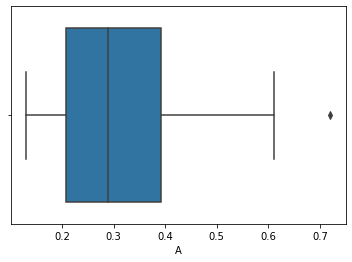

```python
sns.boxplot(x=dfA)
```

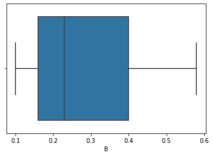

```python
sns.boxplot(x=dfB)
```